# Henderson_assign05

Jesse Henderson

Feburary 19th, 2021

### Instructions

**For each question below, show code.** Once you’ve completed things, don’t forget to to upload this document (knitted version please!) to CANVAS.

A few tips:

- Don’t forget to knit your document frequently!
- Don’t forget to `install.packages()` and load them using `library()`.
- Don’t forget to use `?` or `help()` if you’re unsure about a function
- **EXPLAIN WHAT YOUR RESULTS MEAN!** Think about the numbers and visualizations and explain, in words, what they mean.
- Make sure you label all axes and legends and add a title to your plots and maps.

**23 points total + 2 points extra-credit**

**1. Use `tidycensus` to download 1. total Population and 2. one other variable that you are interested in investigating in all census tracts for a state of your choosing. Store this data in a new object. What is the class of the object? (2 points)** Hint: Since we will be mapping our data, make sure you include use `geometry = TRUE` in `get_acs()`

```r
v19 <- load_variables(year = 2019,
               dataset = "acs5",
               cache = TRUE)

view(v19)
```

```r
#B24122_019, farmers, ranchers, other agricultural jobs.
#B01003_001, total population

census_api_key("e1a4b707937d8c05b51fb49433e4204fe5982861", overwrite = T)

UT <- get_acs(geography = "tract", variables = c(total_population = "B01003_001", ag_jobs = "B24114_019"), year = 2019, state = "UT", geometry = TRUE)
#geometry false to make the data tidy for census calculations.
UT_geofalse <- get_acs(geography = "tract", variables = c(total_population = "B01003_001", ag_jobs = "B24114_019"), year = 2019, state = "UT", geometry = FALSE)
#for problem 6, easier to run this through county instead of tracts.
UTcountygeo <- get_acs(geography = "county", variables = c(total_population = "B01003_001"), year = 2019, state = "UT", geometry = TRUE)
```

**2. Is the data set you downloaded in question 1 projected or unprojected? Explain in words how you know this. (2 points)**

This dataset is NOT projected because the geographic CRS is NAD83, this is just a datum and is not a projected coordinate system. Using the head function with geometry “true” in get_acs, there is a field named geographic CRS and this is where I’m getting this info. NAD83 is a geographic coordinate system meaning it’s 3 dimensional, projected coordinate systems are 2 dimensional. Essentially taking a 3D system into a 2D system and there is no way to maintain all data to be correct accuracy when projecting.

```r
head(UT)
```

```
## Simple feature collection with 6 features and 5 fields
## geometry type:  POLYGON
## dimension:      XY
## bbox:           xmin: -113.0855 ymin: 37.649 xmax: -111.872 ymax: 41.2847
## geographic CRS: NAD83
##         GEOID                                         NAME         variable
## 1 49057200203     Census Tract 2002.03, Weber County, Utah total_population
## 2 49057200203     Census Tract 2002.03, Weber County, Utah          ag_jobs
## 3 49021110400         Census Tract 1104, Iron County, Utah total_population
## 4 49021110400         Census Tract 1104, Iron County, Utah          ag_jobs
## 5 49035112822 Census Tract 1128.22, Salt Lake County, Utah total_population
## 6 49035112822 Census Tract 1128.22, Salt Lake County, Utah          ag_jobs
##   estimate moe                       geometry
## 1     5135 361 POLYGON ((-111.9694 41.2721...
## 2       NA  NA POLYGON ((-111.9694 41.2721...
## 3     4476 545 POLYGON ((-113.0855 37.6490...
## 4       NA  NA POLYGON ((-113.0855 37.6490...
## 5     5323 334 POLYGON ((-111.8908 40.5516...
## 6       NA  NA POLYGON ((-111.8908 40.5516...
```

```r
head(UT_geofalse)
```

```
## # A tibble: 6 x 5
##   GEOID       NAME                                 variable       estimate   moe
##   <chr>       <chr>                                <chr>             <dbl> <dbl>
## 1 49001100100 Census Tract 1001, Beaver County, U~ total_populat~     3319   189
## 2 49001100100 Census Tract 1001, Beaver County, U~ ag_jobs              NA    NA
## 3 49001100200 Census Tract 1002, Beaver County, U~ total_populat~     3198   189
## 4 49001100200 Census Tract 1002, Beaver County, U~ ag_jobs              NA    NA
## 5 49003960100 Census Tract 9601, Box Elder County~ total_populat~     3265   359
## 6 49003960100 Census Tract 9601, Box Elder County~ ag_jobs              NA    NA
```

**3. Which census tract has the highest total population estimate?**

The tract with the highest estimated population is 1131.07 in Salt Lake County, Utah.The estimated population is 31,161.

```r
#splitting these on the chart to see easier
UT <- separate(UT, NAME, into = c("tract", "county", "state"), sep=",")
head(UT)
```

```
## Simple feature collection with 6 features and 7 fields
## geometry type:  POLYGON
## dimension:      XY
## bbox:           xmin: -113.0855 ymin: 37.649 xmax: -111.872 ymax: 41.2847
## geographic CRS: NAD83
##         GEOID                tract            county state         variable
## 1 49057200203 Census Tract 2002.03      Weber County  Utah total_population
## 2 49057200203 Census Tract 2002.03      Weber County  Utah          ag_jobs
## 3 49021110400    Census Tract 1104       Iron County  Utah total_population
## 4 49021110400    Census Tract 1104       Iron County  Utah          ag_jobs
## 5 49035112822 Census Tract 1128.22  Salt Lake County  Utah total_population
## 6 49035112822 Census Tract 1128.22  Salt Lake County  Utah          ag_jobs
##   estimate moe                       geometry
## 1     5135 361 POLYGON ((-111.9694 41.2721...
## 2       NA  NA POLYGON ((-111.9694 41.2721...
## 3     4476 545 POLYGON ((-113.0855 37.6490...
## 4       NA  NA POLYGON ((-113.0855 37.6490...
## 5     5323 334 POLYGON ((-111.8908 40.5516...
## 6       NA  NA POLYGON ((-111.8908 40.5516...
```

```r
UT_geofalse = subset(UT_geofalse, select = -c(moe,GEOID))

#removing unnecessary info
UT = subset(UT, select = -c(moe,GEOID))

UT$county <- gsub( "^ ", "", UT$county)
UT$state <- gsub( "^ ", "", UT$state)
UT$tract <- gsub( "^ ", "", UT$tract)

#pivoting to improve readability and easier for calculations
UT_geofalse <- UT_geofalse %>%
  pivot_wider(names_from = variable, values_from = estimate)

head(UT_geofalse)
```

```
## # A tibble: 6 x 3
##   NAME                                      total_population ag_jobs
##   <chr>                                                <dbl>   <dbl>
## 1 Census Tract 1001, Beaver County, Utah                3319      NA
## 2 Census Tract 1002, Beaver County, Utah                3198      NA
## 3 Census Tract 9601, Box Elder County, Utah             3265      NA
## 4 Census Tract 9602, Box Elder County, Utah             7929      NA
## 5 Census Tract 9603, Box Elder County, Utah             8960      NA
## 6 Census Tract 9604, Box Elder County, Utah             4913      NA
```

```r
head(UTcountygeo)
```

```
## Simple feature collection with 6 features and 5 fields
## geometry type:  MULTIPOLYGON
## dimension:      XY
## bbox:           xmin: -112.9014 ymin: 37.00032 xmax: -109.048 ymax: 41.25163
## geographic CRS: NAD83
##   GEOID                 NAME         variable estimate moe
## 1 49019   Grand County, Utah total_population     9640  NA
## 2 49025    Kane County, Utah total_population     7484  NA
## 3 49043  Summit County, Utah total_population    41103  NA
## 4 49007  Carbon County, Utah total_population    20308  NA
## 5 49051 Wasatch County, Utah total_population    31708  NA
## 6 49047  Uintah County, Utah total_population    36084  NA
##                         geometry
## 1 MULTIPOLYGON (((-110.179 38...
## 2 MULTIPOLYGON (((-112.901 37...
## 3 MULTIPOLYGON (((-111.648 40...
## 4 MULTIPOLYGON (((-111.2475 3...
## 5 MULTIPOLYGON (((-111.6207 4...
## 6 MULTIPOLYGON (((-110.0476 3...
```

```r
#arranging the column to show highest population estimate
UT_hi_poptract <- UT_geofalse %>%
  arrange(desc(total_population))

head(UT_hi_poptract)
```

```
## # A tibble: 6 x 3
##   NAME                                          total_population ag_jobs
##   <chr>                                                    <dbl>   <dbl>
## 1 Census Tract 1131.07, Salt Lake County, Utah             31161      NA
## 2 Census Tract 1130.20, Salt Lake County, Utah             21460      NA
## 3 Census Tract 1143, Salt Lake County, Utah                20297      NA
## 4 Census Tract 2708.01, Washington County, Utah            18327      NA
## 5 Census Tract 1307.02, Tooele County, Utah                17429      NA
## 6 Census Tract 1151.06, Salt Lake County, Utah             17049      NA
```

**4. How many census tracts have a current total population estimate above 10,000? Plot only these census tracts. (2 points)**

There are 27 census tracts in Utah with higher than 10,000 estimated total population.

```r
#filtering to 10000 plus
UT_hi_poptract2 <- UT_hi_poptract %>%
  filter(total_population > 10000)

#just to get a view of how many there are (27)
head(UT_hi_poptract2,100)
```

```
## # A tibble: 27 x 3
##    NAME                                          total_population ag_jobs
##    <chr>                                                    <dbl>   <dbl>
##  1 Census Tract 1131.07, Salt Lake County, Utah             31161      NA
##  2 Census Tract 1130.20, Salt Lake County, Utah             21460      NA
##  3 Census Tract 1143, Salt Lake County, Utah                20297      NA
##  4 Census Tract 2708.01, Washington County, Utah            18327      NA
##  5 Census Tract 1307.02, Tooele County, Utah                17429      NA
##  6 Census Tract 1151.06, Salt Lake County, Utah             17049      NA
##  7 Census Tract 1254.03, Davis County, Utah                 14505      NA
##  8 Census Tract 1261.04, Davis County, Utah                 14217      NA
##  9 Census Tract 1262.02, Davis County, Utah                 13785      NA
## 10 Census Tract 22.01, Utah County, Utah                    13301      NA
## # ... with 17 more rows
```

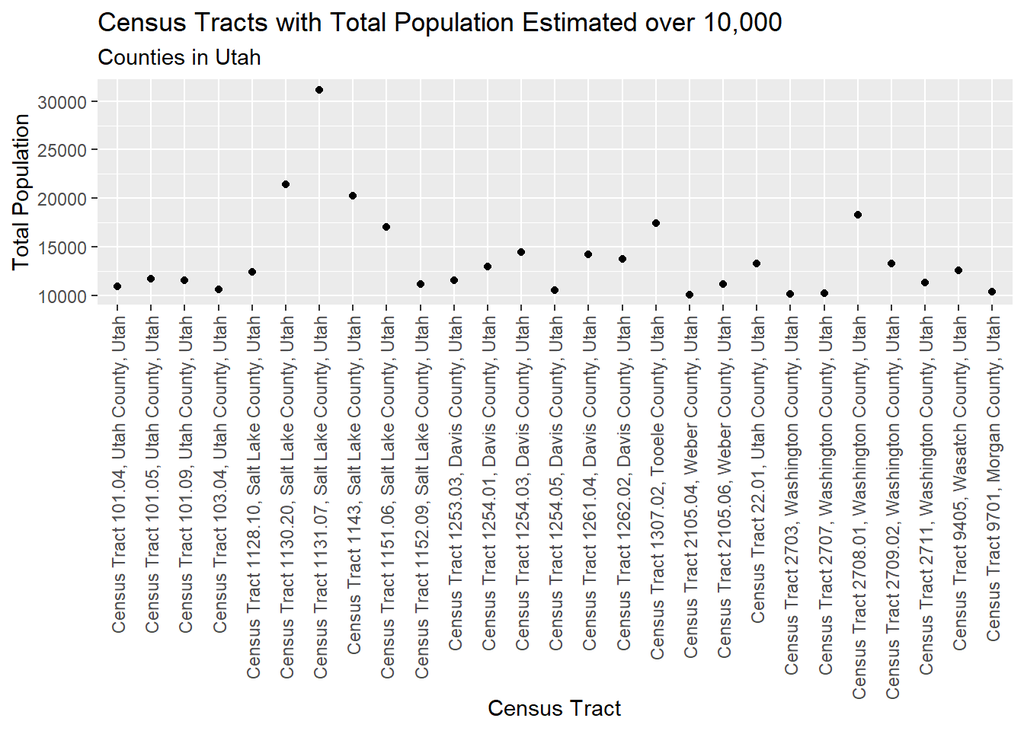

```r
UT_hi_poptract2 %>%
ggplot() +
  geom_point(mapping = aes(x = NAME, y = total_population)) +
  labs(title = "Census Tracts with Total Population Estimated over 10,000",
       subtitle = "Counties in Utah",
       y = "Total Population",
       x = "Census Tract") +
  theme(axis.text.x = element_text(angle = 90, vjust = 0.5, hjust=1))
```

**5. Reproject your census tract data to [USA Contiguous Albers Equal Area Conic](http://spatialreference.org/ref/esri/usa-contiguous-albers-equal-area-conic/). Plot the original and the reprojected data sets. Do you see any difference? (3 points)**

Yes there are noticeable differences in how the tracts are viewed after plotting. The non projected image is basically just a standard textbook style view of the state while the projected version is now tied to specific geographic locations that are preserving area. It is preserving area because of the projection method selected (Albers Equal Area Conic projection).

```r
#viewing the coordinate information
st_crs(UT)
```

```
## Coordinate Reference System:
##   User input: NAD83
##   wkt:
## GEOGCRS["NAD83",
##     DATUM["North American Datum 1983",
##         ELLIPSOID["GRS 1980",6378137,298.257222101,
##             LENGTHUNIT["metre",1]]],
##     PRIMEM["Greenwich",0,
##         ANGLEUNIT["degree",0.0174532925199433]],
##     CS[ellipsoidal,2],
##         AXIS["latitude",north,
##             ORDER[1],
##             ANGLEUNIT["degree",0.0174532925199433]],
##         AXIS["longitude",east,
##             ORDER[2],
##             ANGLEUNIT["degree",0.0174532925199433]],
##     ID["EPSG",4269]]
```

```r
#reprojecting into albers equal area conic
UT_conic <- st_transform(UT, CRS("+proj=aea +lat_1=29.5 +lat_2=45.5 +lat_0=37.5 +lon_0=-96 +x_0=0 +y_0=0 +ellps=GRS80 +datum=NAD83 +units=m +no_defs"))
UT_conic_county <- st_transform(UTcountygeo, CRS("+proj=aea +lat_1=29.5 +lat_2=45.5 +lat_0=37.5 +lon_0=-96 +x_0=0 +y_0=0 +ellps=GRS80 +datum=NAD83 +units=m +no_defs"))

#viewing the coordinate information
st_crs(UT_conic)
```

```
## Coordinate Reference System:
##   User input: PROJCRS["unknown",
##     BASEGEOGCRS["unknown",
##         DATUM["North American Datum 1983",
##             ELLIPSOID["GRS 1980",6378137,298.257222101,
##                 LENGTHUNIT["metre",1]],
##             ID["EPSG",6269]],
##         PRIMEM["Greenwich",0,
##             ANGLEUNIT["degree",0.0174532925199433],
##             ID["EPSG",8901]]],
##     CONVERSION["unknown",
##         METHOD["Albers Equal Area",
##             ID["EPSG",9822]],
##         PARAMETER["Latitude of false origin",37.5,
##             ANGLEUNIT["degree",0.0174532925199433],
##             ID["EPSG",8821]],
##         PARAMETER["Longitude of false origin",-96,
##             ANGLEUNIT["degree",0.0174532925199433],
##             ID["EPSG",8822]],
##         PARAMETER["Latitude of 1st standard parallel",29.5,
##             ANGLEUNIT["degree",0.0174532925199433],
##             ID["EPSG",8823]],
##         PARAMETER["Latitude of 2nd standard parallel",45.5,
##             ANGLEUNIT["degree",0.0174532925199433],
##             ID["EPSG",8824]],
##         PARAMETER["Easting at false origin",0,
##             LENGTHUNIT["metre",1],
##             ID["EPSG",8826]],
##         PARAMETER["Northing at false origin",0,
##             LENGTHUNIT["metre",1],
##             ID["EPSG",8827]]],
##     CS[Cartesian,2],
##         AXIS["(E)",east,
##             ORDER[1],
##             LENGTHUNIT["metre",1,
##                 ID["EPSG",9001]]],
##         AXIS["(N)",north,
##             ORDER[2],
##             LENGTHUNIT["metre",1,
##                 ID["EPSG",9001]]]]
```

[output cut: 25 more lines]

```
##         PARAMETER["Easting at false origin",0,
##             LENGTHUNIT["metre",1],
##             ID["EPSG",8826]],
##         PARAMETER["Northing at false origin",0,
##             LENGTHUNIT["metre",1],
##             ID["EPSG",8827]]],
##     CS[Cartesian,2],
##         AXIS["(E)",east,
##             ORDER[1],
##             LENGTHUNIT["metre",1,
##                 ID["EPSG",9001]]],
##         AXIS["(N)",north,
##             ORDER[2],
##             LENGTHUNIT["metre",1,
##                 ID["EPSG",9001]]]]
```

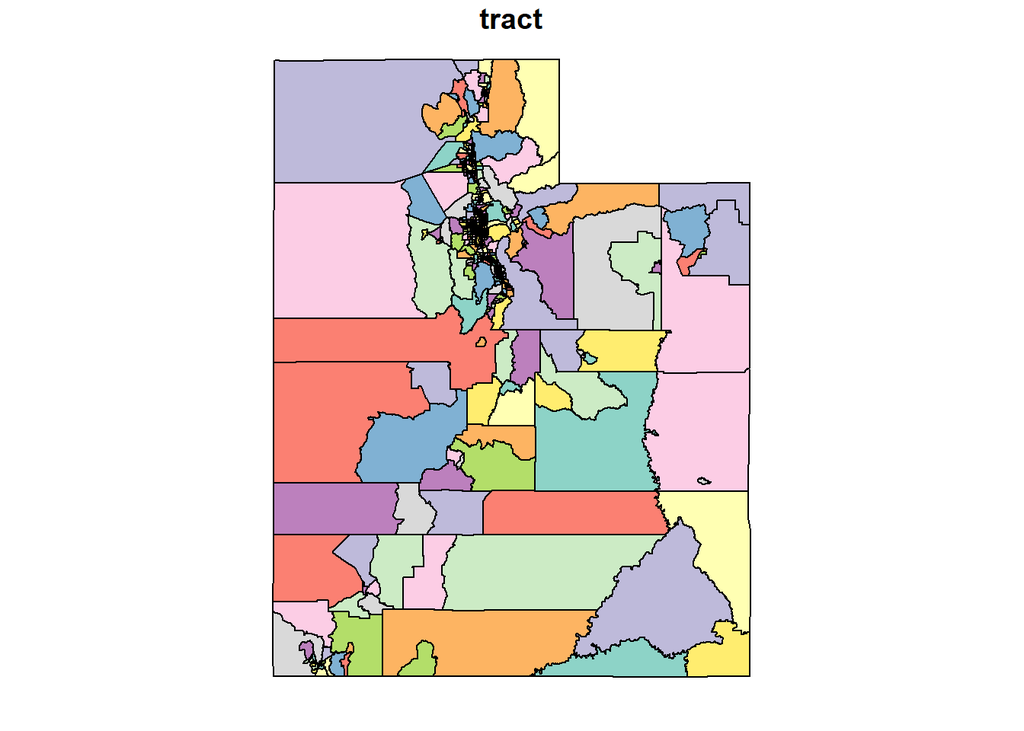

```r
#view unprojected

select(UT, tract) %>%
plot()
```

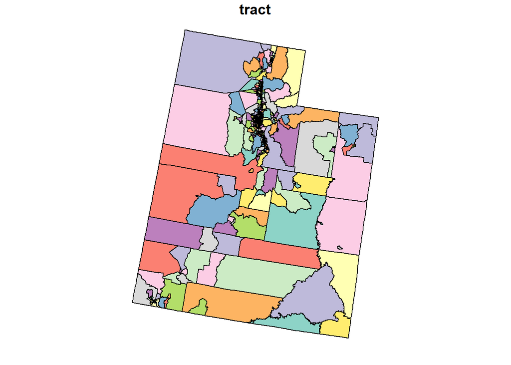

```r
#view projected
select(UT_conic, tract) %>%
plot()
```

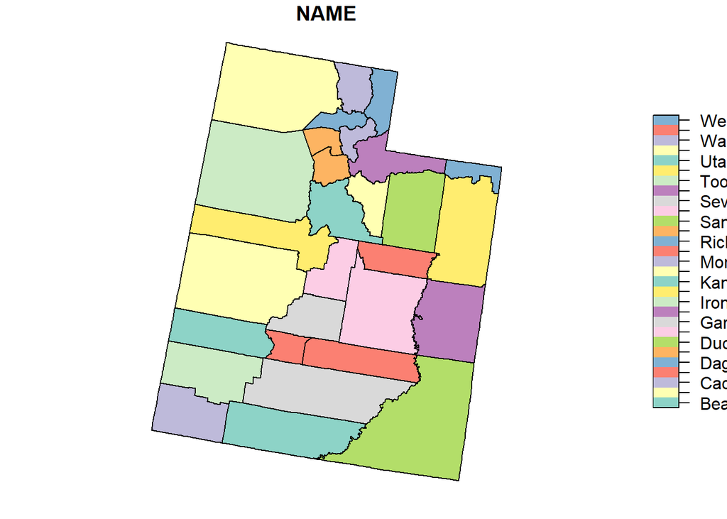

```r
#view county map of Utah
select(UT_conic_county, NAME) %>%
plot()
```

```r
head(UT_conic_county,20)
```

```
## Simple feature collection with 20 features and 5 fields
## geometry type:  MULTIPOLYGON
## dimension:      XY
## bbox:           xmin: -1527755 ymin: 22679.81 xmax: -1090562 ymax: 643914.1
## CRS:            PROJCRS["unknown",
##     BASEGEOGCRS["unknown",
##         DATUM["North American Datum 1983",
##             ELLIPSOID["GRS 1980",6378137,298.257222101,
##                 LENGTHUNIT["metre",1]],
##             ID["EPSG",6269]],
##         PRIMEM["Greenwich",0,
##             ANGLEUNIT["degree",0.0174532925199433],
##             ID["EPSG",8901]]],
##     CONVERSION["unknown",
##         METHOD["Albers Equal Area",
##             ID["EPSG",9822]],
##         PARAMETER["Latitude of false origin",37.5,
##             ANGLEUNIT["degree",0.0174532925199433],
##             ID["EPSG",8821]],
##         PARAMETER["Longitude of false origin",-96,
##             ANGLEUNIT["degree",0.0174532925199433],
##             ID["EPSG",8822]],
##         PARAMETER["Latitude of 1st standard parallel",29.5,
##             ANGLEUNIT["degree",0.0174532925199433],
##             ID["EPSG",8823]],
##         PARAMETER["Latitude of 2nd standard parallel",45.5,
##             ANGLEUNIT["degree",0.0174532925199433],
##             ID["EPSG",8824]],
##         PARAMETER["Easting at false origin",0,
##             LENGTHUNIT["metre",1],
##             ID["EPSG",8826]],
##         PARAMETER["Northing at false origin",0,
##             LENGTHUNIT["metre",1],
##             ID["EPSG",8827]]],
##     CS[Cartesian,2],
##         AXIS["(E)",east,
##             ORDER[1],
##             LENGTHUNIT["metre",1,
##                 ID["EPSG",9001]]],
##         AXIS["(N)",north,
```

[output cut: 11 more lines]

```
## 7  49037  San Juan County, Utah total_population    15302  NA
## 8  49015     Emery County, Utah total_population    10117  NA
## 9  49017  Garfield County, Utah total_population     4998  NA
## 10 49035 Salt Lake County, Utah total_population  1133646  NA
##                          geometry
## 1  MULTIPOLYGON (((-1213587 24...
## 2  MULTIPOLYGON (((-1472247 13...
## 3  MULTIPOLYGON (((-1303943 47...
## 4  MULTIPOLYGON (((-1288102 36...
## 5  MULTIPOLYGON (((-1307649 43...
## 6  MULTIPOLYGON (((-1192106 31...
## 7  MULTIPOLYGON (((-1352824 54...
## 8  MULTIPOLYGON (((-1313589 23...
## 9  MULTIPOLYGON (((-1448007 16...
## 10 MULTIPOLYGON (((-1354609 48...
```

**6. Create a new sf with only three counties in your state. What is the sum of the shape areas in these three counties? (3 points)** Hint use `st_area()`.

```r
#filtering counties down then using area function and then addaing the 3 areas together using sum.
UT_conicarea <- UT_conic_county %>%
filter(NAME == c("Davis County, Utah","Weber County, Utah","Cache County, Utah")) %>%
  st_area() %>%
  sum()

head(UT_conicarea)
```

```
## 1708933241 [m^2]
```

**7. Plot the new sf you created in question 6 using ggplot2.**

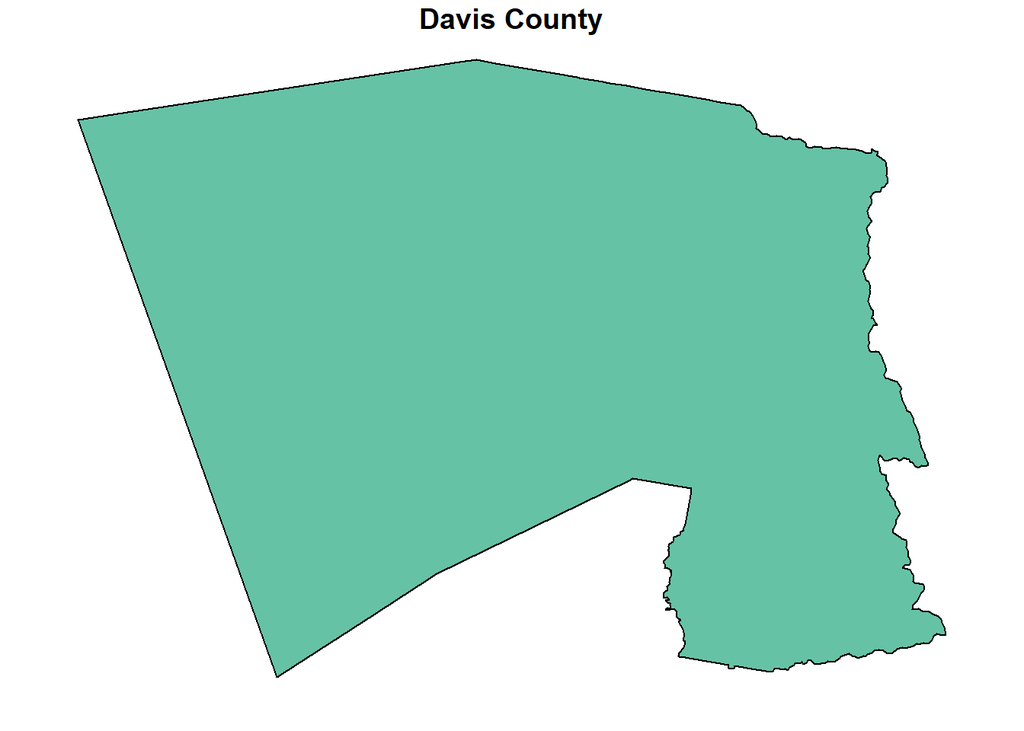

```r
#I know this probably isn't the cleanest way to do it, but it is the way it made sense to me. I'm filtering for each individual county then plotting.
county_groups <- UT_conic_county %>%
  group_by("NAME") %>%
  select(NAME) %>%
  filter(NAME == c("Davis County, Utah")) %>%
  plot(main = "Davis County")
```

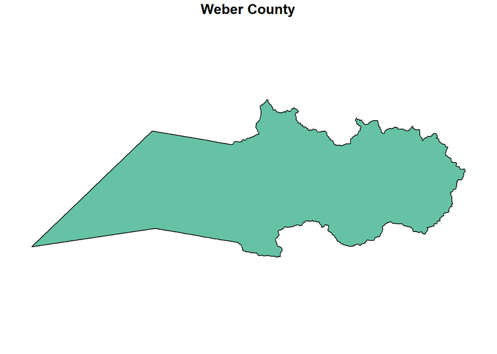

```r
county_groups2 <- UT_conic_county %>%
  group_by("NAME") %>%
  select(NAME) %>%
  filter(NAME == c("Weber County, Utah")) %>%
  plot(main = "Weber County")
```

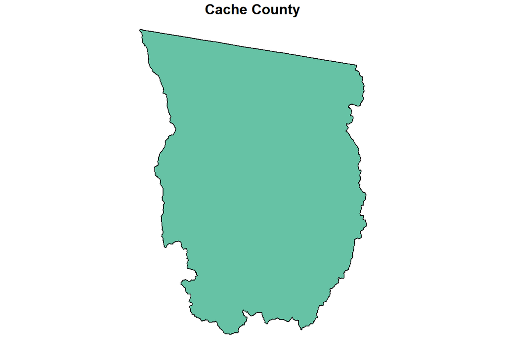

```r
county_groups3 <- UT_conic_county %>%
  group_by("NAME") %>%
  select(NAME) %>%
  filter(NAME == c("Cache County, Utah")) %>%
  plot(main = "Cache County")
```

**8. The Environmental Protection Agency keeps a Toxics Release Inventory (TRI) of toxic chemical releases and pollution prevention activities reported by industrial and federal facilities. Download the TRI data for the state you are mapping in this assignment: https://www.epa.gov/frs/epa-frs-facilities-state-single-file-csv-download. Read your TRI .csv into R and turn it into a MULTIPOINT spatial object. (2 points)**

```r
#viewing downloaded csv file for Utah
UT_TRI <- read.csv("STATE_SINGLE_UT.csv")

#removing NA values
UT_TRI <- UT_TRI[!is.na(UT_TRI$LONGITUDE83),]
UT_TRI <- UT_TRI[!is.na(UT_TRI$LATITUDE83),]
glimpse(UT_TRI)
```

```
## Rows: 31,533
## Columns: 39
## $ FRS_FACILITY_DETAIL_REPORT_URL <chr> "https://ofmpub.epa.gov/frs_public2/...
## $ REGISTRY_ID                    <dbl> 110010369797, 110046594798, 11002458...
## $ PRIMARY_NAME                   <chr> "WILD ROSE RESOURCES", "R. CHAPMAN C...
## $ LOCATION_ADDRESS               <chr> "GULF STATE OIL WELLS", "HARMSTON PL...
## $ SUPPLEMENTAL_LOCATION          <chr> "", "", "NORTH OF PELICAN LAKE", "",...
## $ CITY_NAME                      <chr> "17 MI. SOUTHEAST OF ROOSEVELT", "2 ...
## $ COUNTY_NAME                    <chr> "UINTAH", "DUCHESNE", "UINTAH", "TOO...
## $ FIPS_CODE                      <chr> "49047", "49013", "UT047", "UT045", ...
## $ STATE_CODE                     <chr> "UT", "UT", "UT", "UT", "UT", "UT", ...
## $ STATE_NAME                     <chr> "UTAH", "UTAH", "UTAH", "UTAH", "UTA...
## $ COUNTRY_NAME                   <chr> "UNITED STATES", "UNITED STATES", ""...
## $ POSTAL_CODE                    <chr> "84066", "84066", "84021", "84070", ...
## $ FEDERAL_FACILITY_CODE          <chr> "", "", "", "", "", "", "", "", "", ...
```

[output cut: 26 more lines]

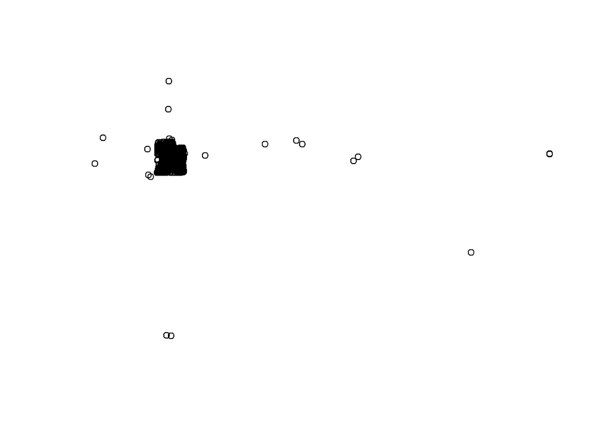

```r
#creating a system to project the coordinates.
UT_TRI_sf = st_as_sf(UT_TRI,coords=c("LONGITUDE83","LATITUDE83"), crs=4269)

#for some reason there are a lot of outlier points and then a large black shape of Utah. Not sure where those outlier points are coming from. Possible errors in data collection or input.
plot(st_geometry(UT_TRI_sf))
```

**9. Plot TRI data in only the 3 counties you selected in question 6. (3 points)** Hint: You can use `st_intersection()` to find overlap between spatial objects

[figure not shown]

```r
 #I had all kinds of problems with the st_intersection function and tried other things. Couldn't figure anything out.
CG <- c(county_groups,county_groups2,county_groups3)

Combined <- intersect(county_groups,UT_TRI_sf)
plot(Combined)
```

**10. Use ggplot2 to create a choropleth map of your state for the second Census variable you selected in question 1.**

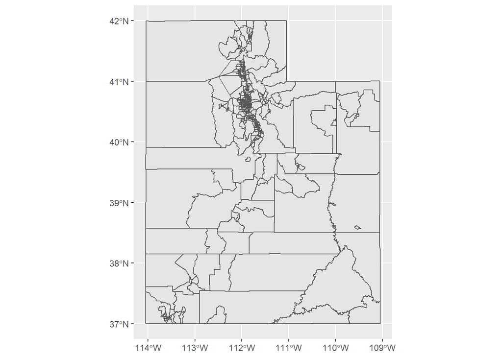

```r
 # can't quite get this to work out right. Don't know how to tell the plot to use agricultural jobs as the indexing for the map.
UTCP <- UT %>%
  filter(variable == "ag_jobs")

ggplot(data = UTCP) +
    geom_sf(aes())
```

```r
head(UT)
```

```
## Simple feature collection with 6 features and 5 fields
## geometry type:  POLYGON
## dimension:      XY
## bbox:           xmin: -113.0855 ymin: 37.649 xmax: -111.872 ymax: 41.2847
## geographic CRS: NAD83
##                  tract           county state         variable estimate
## 1 Census Tract 2002.03     Weber County  Utah total_population     5135
## 2 Census Tract 2002.03     Weber County  Utah          ag_jobs       NA
## 3    Census Tract 1104      Iron County  Utah total_population     4476
## 4    Census Tract 1104      Iron County  Utah          ag_jobs       NA
## 5 Census Tract 1128.22 Salt Lake County  Utah total_population     5323
## 6 Census Tract 1128.22 Salt Lake County  Utah          ag_jobs       NA
##                         geometry
## 1 POLYGON ((-111.9694 41.2721...
## 2 POLYGON ((-111.9694 41.2721...
## 3 POLYGON ((-113.0855 37.6490...
## 4 POLYGON ((-113.0855 37.6490...
## 5 POLYGON ((-111.8908 40.5516...
## 6 POLYGON ((-111.8908 40.5516...
```

```r
head(UTCP)
```

```
## Simple feature collection with 6 features and 5 fields
## geometry type:  POLYGON
## dimension:      XY
## bbox:           xmin: -113.0855 ymin: 37.649 xmax: -111.7051 ymax: 41.2847
## geographic CRS: NAD83
##                  tract           county state variable estimate
## 1 Census Tract 2002.03     Weber County  Utah  ag_jobs       NA
## 2    Census Tract 1104      Iron County  Utah  ag_jobs       NA
## 3 Census Tract 1128.22 Salt Lake County  Utah  ag_jobs       NA
## 4    Census Tract 2106     Weber County  Utah  ag_jobs       NA
## 5 Census Tract 1135.21 Salt Lake County  Utah  ag_jobs       NA
## 6   Census Tract 11.06      Utah County  Utah  ag_jobs       NA
##                         geometry
## 1 POLYGON ((-111.9694 41.2721...
## 2 POLYGON ((-113.0855 37.6490...
## 3 POLYGON ((-111.8908 40.5516...
## 4 POLYGON ((-112.0467 41.1803...
## 5 POLYGON ((-111.9869 40.6655...
## 6 POLYGON ((-111.7255 40.2972...
```

## 3. Reflection (3 points)

When conducting data analysis, you as a researcher not only have to demonstrate your technical skills but consider your choices and their impacts. Reflecting on data analysis helps you document your process, what worked, what didn’t, and how you might improve. At the end of each class assignment you will asked to write a sort reflection.

This reflection is free-form. Use this as a space to note:

I’ve found this assignment interesting because I can use R for spatial data. This in tandem with ArcGIS Pro could create a lot of powerful data calculations.

I haven’t found other analysis tools to use but I’m sure as soon as I look a little deeper into my data there will be something I become interested in.

I found it interesting that you can create shapefiles within R and not have to just import them. This could have some interesting uses for data calculations using matrices.

I’m slowly getting more and more familiar with how to run all the functions within dplyr package which is helping. I’m learning how they really function and what not to do while using them. Some of the functions are quite finicky and don’t like when you do certain things even if the function comes out as correctly run.

## 4. Extra Credit (2 points)

**Write out one of the spatial objects you created above as a .shp file. Use QGIS or ArcGIS to open the shape file. Take a screenshot of the shape file in your GIS program window and insert the image into this Rmarkdown document.**